# R Programlama Serisi : R Grafikleri

Baki SELİM

24/05/2020

### **Temel Grafik Gösterimleri**

Bu kısımda R içerisinde temel grafiklendirme komutu olan “plot()” ile grafikler göstermek istenmiştir.

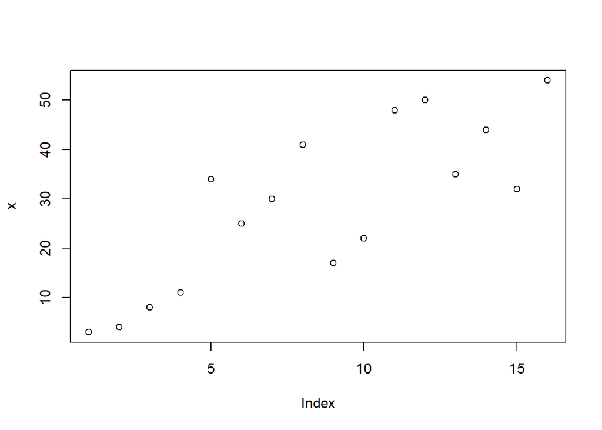

```r
x <- c(3,4,8,11,34,25,30,41,17,22,48,50,35,44,32,54)

plot(x)
```

#### **1. Histogram Grafiği :**

Histogram, gruplandırılmış bir veri dağılımının sütun grafiğiyle gösterimidir. Diğer bir ifadeyle, tekrarlı sayılardan oluşan verilerin, uygulanan işlemlerden sonra önce tabloya, tablodan yararlanarak grafiğe aktarılmasıdır.[1]

histogram grafiğinin kod dizimi :

> **hist(v,main,xlab,xlim,ylim,breaks,col,border)**
- v : numerik veriler içeren vektör/ler
- main : Grafiğin başlığı
- xlab : x ekseninin yazısı
- xlim : x ekseninin belirli aralıkta olmasını sağlar
- ylim : y ekseninin belirli aralıkta olmasını sağlar
- col : grafiğin renk seçimini gerçekleştirir
- border : çubukların kenarlarının ne renk olacağını belirler
- breaks : çubuk sayısının detaylı olması istendiğinde kullanılır.
- labels : sıklıkları göstermede kullanılır. (TRUE/FALSE)

**Örnek 1**: Sıklık Değerleri ile Grafik Çizdirilmesi

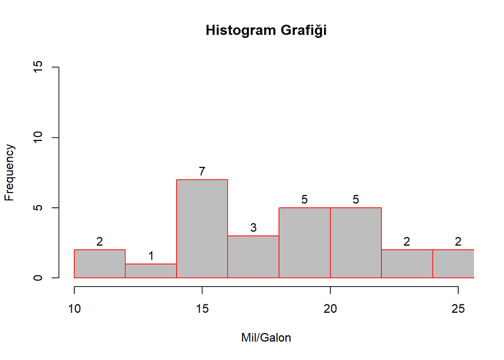

```r
hist(mtcars$mpg ,
     main = "Histogram Grafiği" ,
     col  = "gray" ,
     xlab = "Mil/Galon",
     xlim = c(10,25),
     ylim = c(0,15),
     border = "red",
     breaks = 10,
     labels = TRUE
     )
```

**Örnek 2** : Olasılık Yoğunluk Fonksiyonu

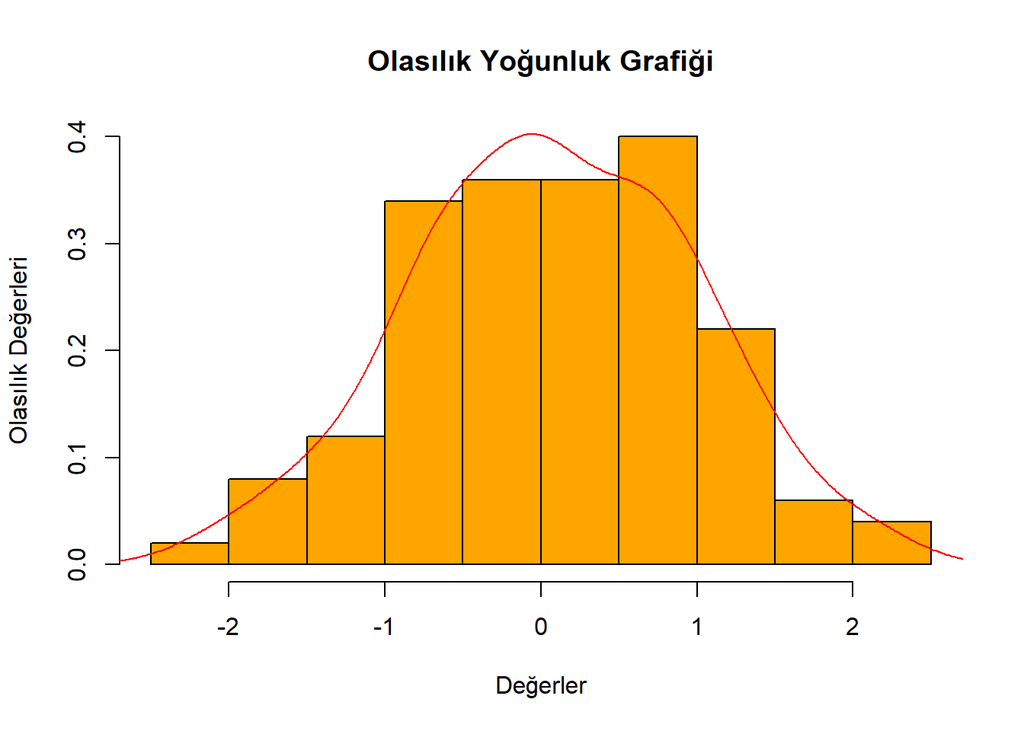

```r
x1 <- rnorm(100)

hist(x1,
     main = "Olasılık Yoğunluk Grafiği",
     col  = "orange",
     xlab = "Değerler",
     ylab = "Olasılık Değerleri",
     prob = TRUE)
lines(density(x1) , col = "red")
```

> ek : lines(density(x1) , type = “h”) komutu ile yoğunluk farklı biçimde gösterilebilir.

**Örnek 3** : Birden Fazla Olasılık Yoğunluk Fonksiyonunu Beraber Gösterme ve Ortak Kesişim Noktasını Belirleme :

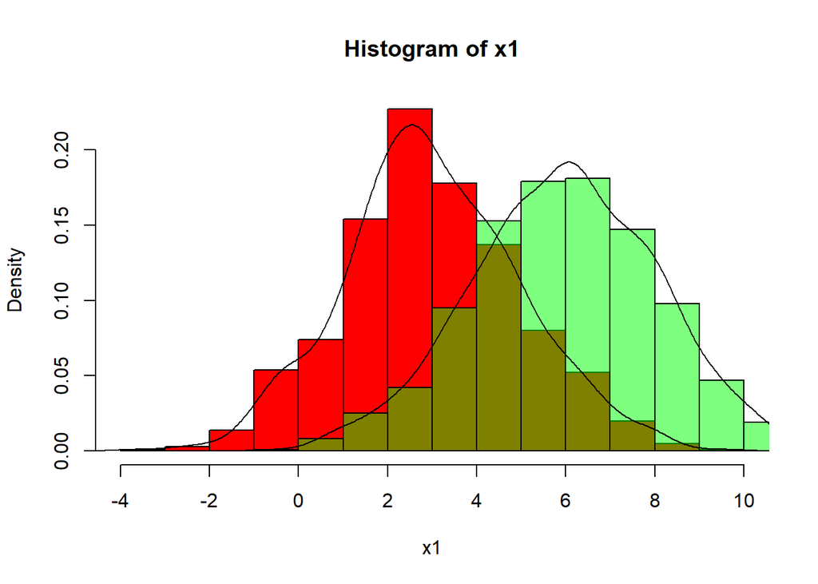

```r
x1  <- rnorm(1000, 3, 2)
x2  <- rnorm(1000, 6, 2)

hist(x1,
     col="red",
     prob= TRUE)
                     # add=t ifadesi mevcut grafige eklemek icin kullanilir
hist(x2,
     add  = T,
     col  = rgb(0, 1, 0, 0.5),
     prob = TRUE)

lines(density(x1))
lines(density(x2))
```

#### **2. Kutu Grafiği**

İstatistik biliminde kutu grafiği bir betimsel istatistik ve istatistiksel grafik aleti olup niceliksel verileri görsel şekilde özetlemek için Amerikan istatistikçi John Tukey tarafından kutu-ve-bıyıklar grafiği adı altında bir açıklayıcı veri analizi aracı olarak ilk defa geliştirilmiştir.[2]

Kutu grafiğinin kod dizimi :

> **boxplot(x,data,notch,varwidth,names,main)**
- x : numerik vektör veya formül
- data : kullanılan veri seti
- notch : mantıksal değişkenken.TRUE olması aktif eder
- names : grup isimlerinin her birini grafiğin altında gösterir
- main : grafik başlığını ifade eder

**Örnek 1** : Temel Kullanım

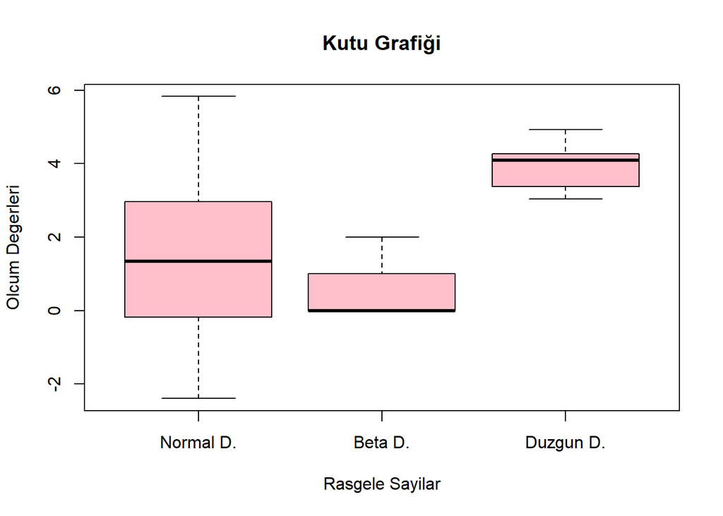

```r
x1 <- rnorm(20,1,2)         # normal dagilimdan secilen 20 sayi
x2 <- rbinom(20,3,0.2)      # binom dagilimindan secilen 20 sayi
x3 <- runif(20,3,5)         # duzgun dagilimindan secilen 20 sayi

dagilim <- cbind(x1,x2,x3)  # vektorler birlestirildi

boxplot(dagilim,
        xlab = "Rasgele Sayilar",
        ylab = "Olcum Degerleri",
        main = "Kutu Grafiği",
        col  = "pink",
        names= c("Normal D.","Beta D.","Duzgun D."),
        )
```

**Örnek 2**: Birden fazla kutu grafiğinin x y üzerinde dağılımı:

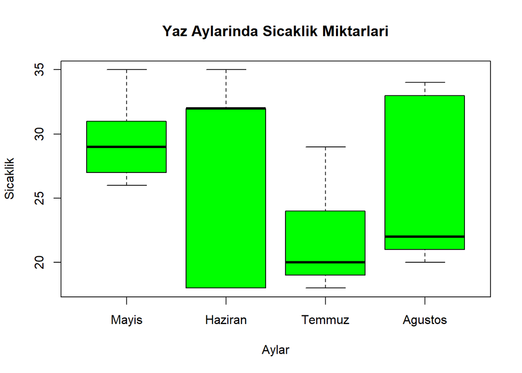

```r
aylar_kutu    <- gl(4,5,labels = c("Mayis","Haziran","Temmuz","Agustos") )
sicaklik_kutu <- sample(18:35,20,replace = TRUE)


library(tibble)
veriset <- tibble(sicaklik_kutu,aylar_kutu)

boxplot(sicaklik_kutu~aylar_kutu ,
        data = veriset,
        xlab = "Aylar",
        ylab = "Sicaklik",
        main = "Yaz Aylarinda Sicaklik Miktarlari",
        col  = "green",
        names= c("Mayis","Haziran","Temmuz","Agustos"))
```

#### **3. Pasta(Pie) Grafiği**

Dairesel grafik, istatistik biliminde betimsel istatistik alanında kategorik verileri görsel bir şekilde betimleyip özetlemek için hazırlanan; içindeki kategori dilimlerini orantısal olarak gösteren bir daire şeklinde sunulan bir gösterim aracıdır.[3]

Pasta / Daire (Pie) grafiğinin kod dizimi :

> **pie(x, labels, radius, main, col, clockwise)**
- x : numerik değerler içeren vektör
- data : kullanılan veri seti
- labes : kategoriler
- radius : yarıçap -1 ile +1 arasında değer alır.
- main : grafik başlığı
- col : dilimlerin renkleri
- clockwise :dilimlerin saat yönünde veya saat yönünün tersine çizilip çizilmediğini gösteren mantıksal bir değerdir.

**Örnek1** : Temel Kullanım

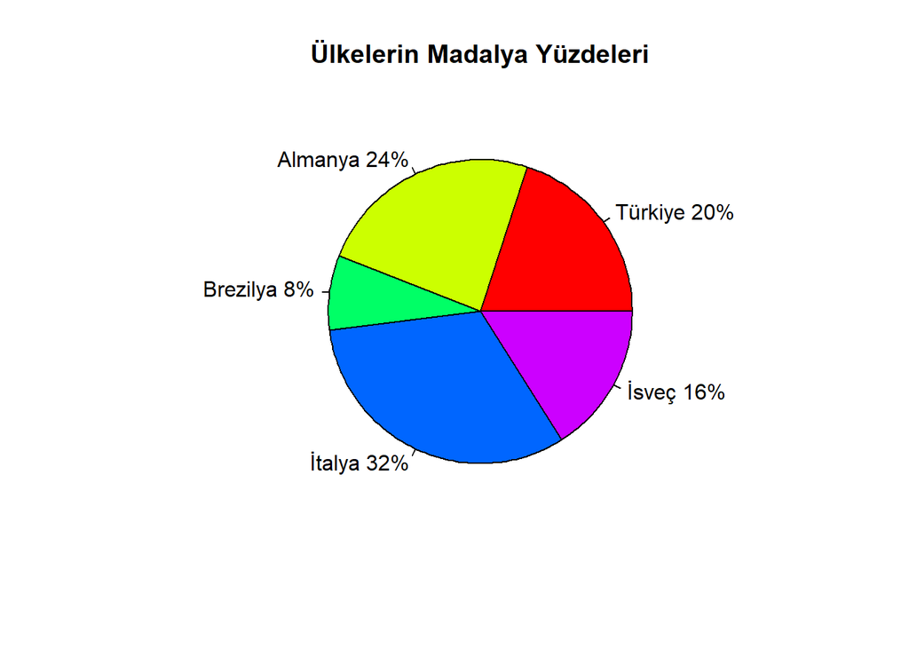

```r
madalya_sayi <- c(10, 12, 4, 16, 8)
ulkeler <- c("Türkiye","Almanya","Brezilya","İtalya","İsveç")
yuzdelik <- round(madalya_sayi/sum(madalya_sayi)*100)       # Yuzdelik degerler yuvarlanarak bulundu

ulkeler <- paste(ulkeler, yuzdelik)                         # Ulkelere yüzdelik degerleri eklendi
ulkeler <- paste(ulkeler,"%",sep="")                        #  % sembolu yazilarin arasina eklendi

pie(madalya_sayi,
    labels = ulkeler,
    col=rainbow(length(ulkeler)),
    main="Ülkelerin Madalya Yüzdeleri")
```

**Örnek 2** : 3D Grafikler de oluşturulabilir.

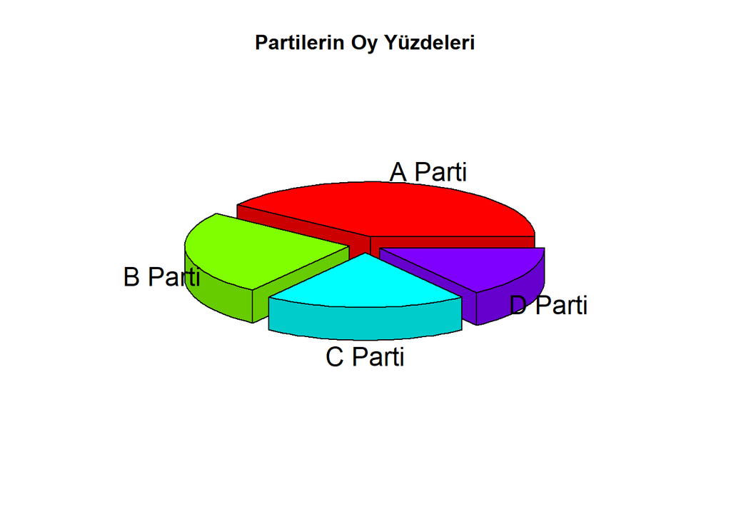

```r
library(plotrix)                    # Kutuphane aktif edilmesi

parcalar <- c(40,25,20,15)
parti <- c("A Parti","B Parti","C Parti","D Parti")   #explode degeri parcalar arasi acikligi ifade eder

pie3D(parcalar,labels=parti,explode=0.1,
      main="Partilerin Oy Yüzdeleri")
```

#### **4. Sütun Grafiği** :

Çubuk grafik, kategorik verileri temsil ettikleri değerlerle orantılı yükseklik veya uzunluktaki dikdörtgen çubuklarla sunan bir grafik veya grafiktir.[4]

Sütun grafiği kod dizimi :

> **barplot(H,xlab,ylab,main, names.arg,col)**
- x : numerik değerler içeren vektör
- xlab : x ekseninin yazısı
- ylab : y ekseninin yazısı
- main : grafiğin başlığı
- col : sütunların renkleri
- names.arg : herbir sütunun isimleri
- horiz : TRUE oldugu durumda yatay sütunlar olusur.
- legend : sütunlara gruplar eklemek icin kullanılır.

**Örnek 1**: Temel Kullanım

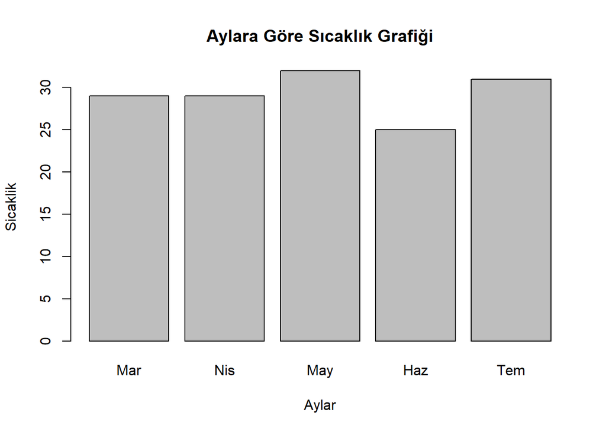

```r
sicaklik_b <- sample(20:35,5,replace = TRUE)
aylar_b    <- c("Mar","Nis","May","Haz","Tem")


barplot(sicaklik_b,
        names.arg=aylar_b,
        xlab="Aylar",
        ylab="Sicaklik",
        col="gray",
        main="Aylara Göre Sıcaklık Grafiği")
```

**Örnek 2** : Gruplanmış Veri / Gelişmiş Gösterim

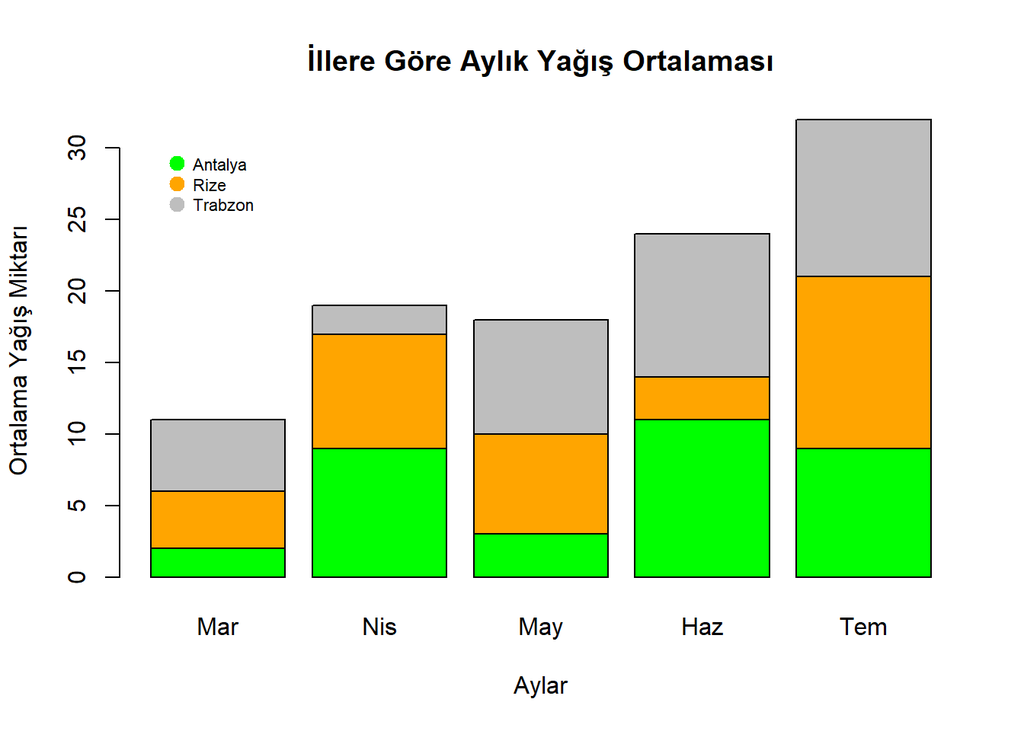

```r
renkler <- c("green","orange","gray")
aylar   <- c("Mar","Nis","May","Haz","Tem")
iller   <- c("Antalya","Rize","Trabzon")

yagis.ort <- matrix(c(2,9,3,11,9,4,8,7,3,12,5,2,8,10,11), nrow = 3, ncol = 5, byrow = TRUE)


barplot(yagis.ort, main = "İllere Göre Aylık Yağış Ortalaması",
        names.arg = aylar,
        xlab = "Aylar", ylab = "Ortalama Yağış Miktarı",
        col = renkler,
        )
legend("topleft",iller ,
       col = renkler ,
       bty = "n", pch=20 , pt.cex = 2, cex = 0.7, horiz = FALSE, inset = c(0.05, 0.05))
```

#### **5. Çizgi Grafiği**

Verilerin yatay ve dikey eksendeki değerleri işaretlenerek bulunan noktaların çizgilerle birleştirilmesi sonucunda elde edilen grafikler çizgi grafiklerdir.[5]

Çizgi grafiği kod dizimi :

> **plot(x, type = “o”,main,xlab,ylab,col)**
- x : veri seti
- main : grafik başlığı
- type : “o” ifadesi çizgi grafiği yapıyor.
- xlab : x ekseninin yazısı
- ylab : y ekseninin yazısı

**Örnek 1** : Temel Gösterim:

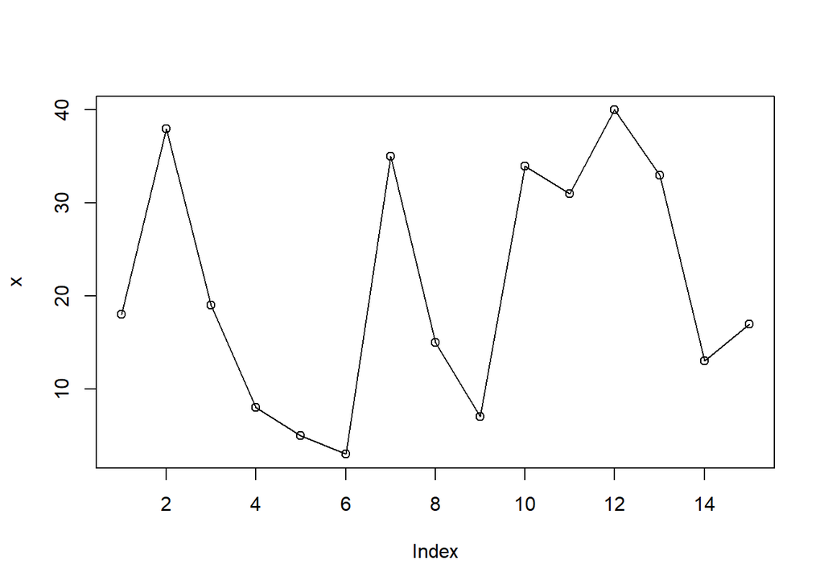

```r
x <- sample(3:40 ,15)
plot(x,type = "o")
```

**Örnek 2** : 2 ve üzeri veriyi tek grafikte gösterme :

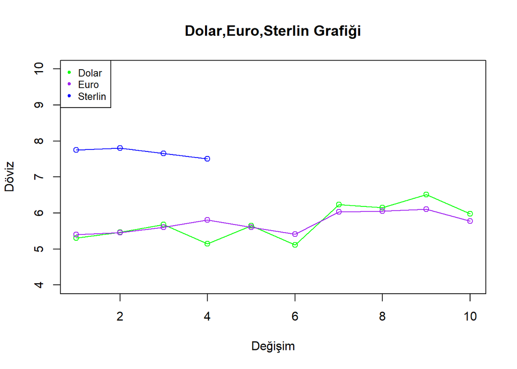

```r
dolar <- c(5.3,5.47,5.68,5.14,5.65,5.11,6.23,6.15,6.51,5.98)    # veri seti olusturuldu
plot(dolar,
     type = "o",
     col = "green" ,
     main = "Dolar,Euro,Sterlin Grafiği",
     ylim = c(4,10),
     ylab = "Döviz",
     xlab = "Değişim")

euro    <- c(5.4,5.45,5.60,5.81,5.60,5.41,6.03,6.05,6.11,5.78)  # eklenecek veri seti
sterlin <- c(7.75,7.80,7.65,7.51)


lines(euro,type = "o",col = "purple")        # euro eklendi
lines(sterlin,type = "o" ,col = "blue")      # sterlin eklendi


legend("topleft",legend = c("Dolar","Euro","Sterlin"),  # sol ust kisma gosterge eklendi
       col = c("Green","Purple","Blue"),
       pch = 20 , cex = 0.8)
```

**Örnek 3** : Gelişmiş Gösterim :

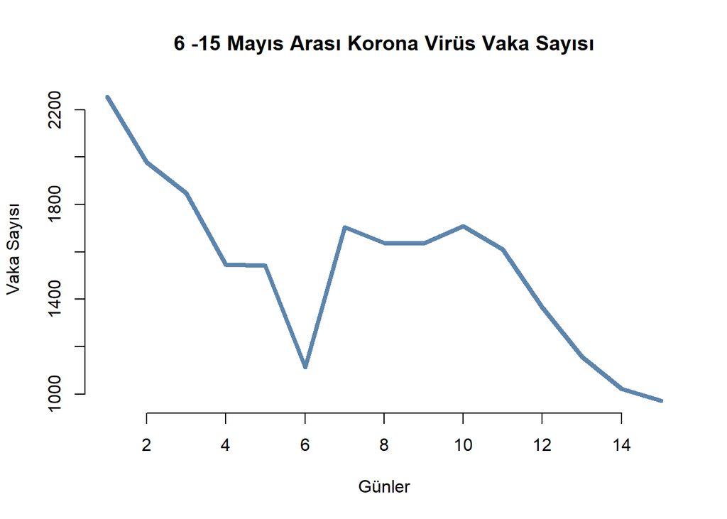

```r
x <- c(1:15)
y <- c(2253,1977,1848,1546,1542,1114,1704,1639,1635,1708,1610,1368,1158,1022,972)


plot(x,y,main = "6 -15 Mayıs Arası Korona Virüs Vaka Sayısı",
     lwd=4 , type="l" , bty="n" ,
     ylab = "Vaka Sayısı" ,
     xlab = "Günler",
     col=rgb(0.2,0.4,0.6,0.8) )
```

#### **6. Saçılım Grafiği**

Saçılım grafikleri, iki sürekli değişken arasında herhangi bir ilişkinin varlığını araştırmak için oluşturulan bir grafik türüdür. [6]

Saçılım grafiğinin kod dizimi :

> **plot(x, y, main, xlab, ylab, xlim, ylim, axes)**
- x : numerik veriler içeren vektör/ler
- y : numerik veriler içeren vektör/ler
- main : Grafiğin başlığı
- xlab : x ekseninin yazısı
- xlim : x ekseninin belirli aralıkta olmasını sağlar
- ylim : y ekseninin belirli aralıkta olmasını sağlar
- axes : her iki eksenin de grafik üzerinde çizilip çizilmemesi gerektiğini belirtir.

**Örnek 1** :

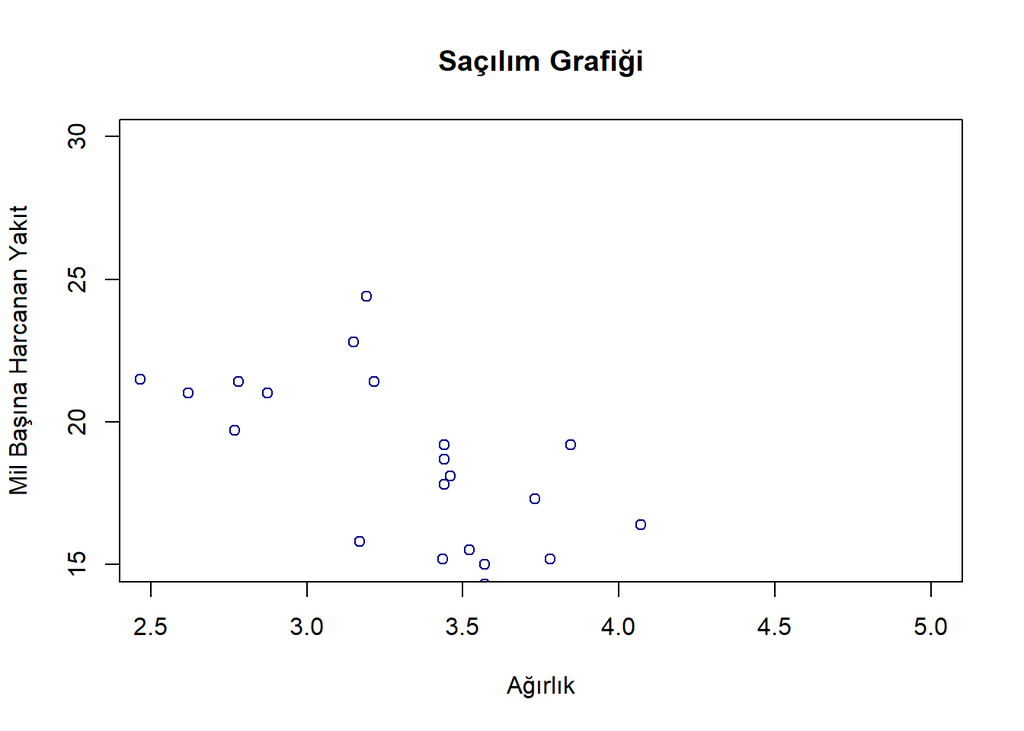

```r
data(mtcars)               # R icerisinde hazir bulunan veri seti kullanildi.

plot(x = mtcars$wt,y = mtcars$mpg,
   xlab = "Ağırlık",
   ylab = "Mil Başına Harcanan Yakıt",
   xlim = c(2.5,5),
   ylim = c(15,30),
   main = "Saçılım Grafiği",
   col  = "darkblue"
)
```

#### **7. Saçılım Grafiği Matrisi**

Saçılım grafiği matrisleri , ikiden fazla değişkenlerin birbirleri üzerinde nasıl saçılım gösterdiğini ifade etmek için kullanılır.

Matris saçılım grafiğinin kod dizimi :

> **pairs(data.frame,labels) veya pairs(~x1+x2+x3 , data = veriseti)**
- x : numerik veriler içeren vektör/ler , x1,x2..vb.
- main : grafiğin başlığı
- labels : değişkenlerin isimlerini ifade eder
- pch : noktaların keskinliğini ayarlamada kullanılır.
- col : vektör halindedir.c(“blue”,“red”..) gibi kullanılır.

**Örnek 1** : 3 farklı değişkenin gösterilmesi :

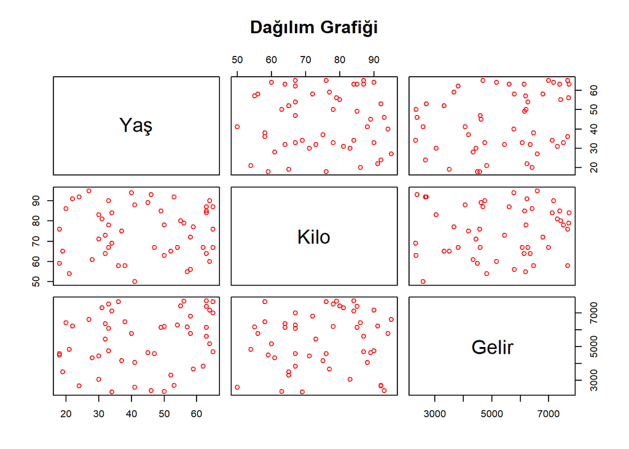

```r
yas    <- c(sample(18:65,50,replace = TRUE))        # vektorler olusturuldu
kilo   <- c(sample(50:95,50,replace = TRUE))
gelir  <- c(sample(2300:8000,50))

veriset <- data.frame(yas,kilo,gelir)               # vektorler bir dataframe ile birlestirildi

pairs(veriset,
      main   = "Dağılım Grafiği",
      labels = c("Yaş","Kilo","Gelir"),
      col    = c("red"))
```

**Örnek 2** : Değişkenler İçerisindeki Grupların Sınıflandırılması :

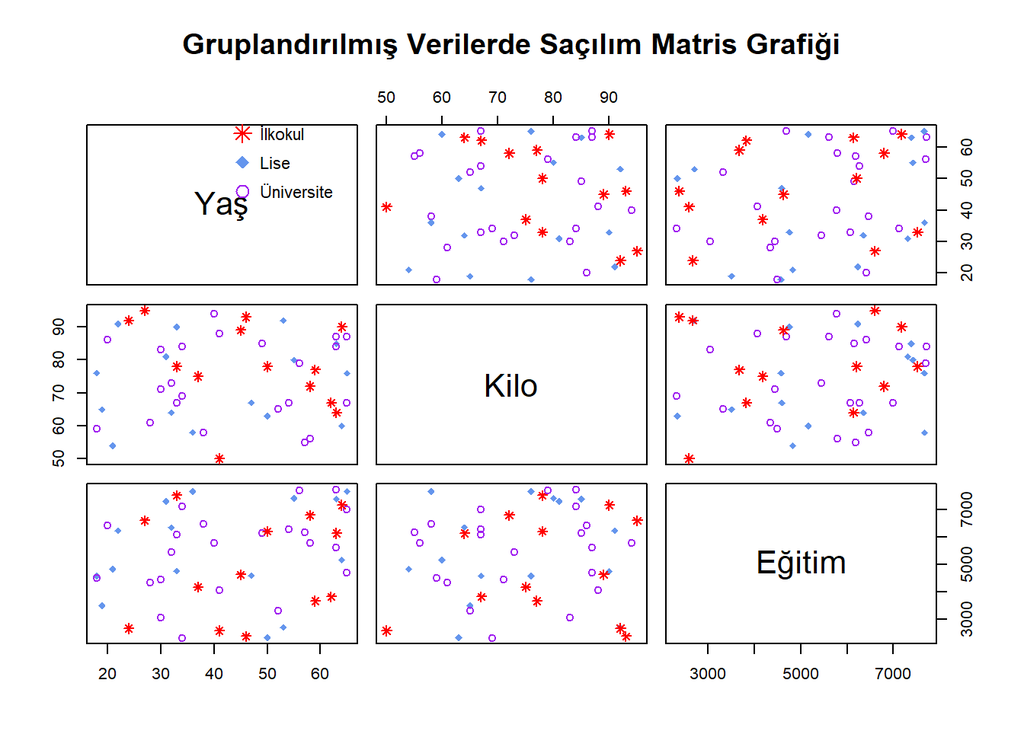

```r
egitim_grubu <- c(sample(c(1,2,3),50,replace = TRUE))
veriset[,4] <- egitim_grubu

pairs(veriset[,1:3],
      col = c("red", "cornflowerblue", "purple")[egitim_grubu],   # gruplara gore renklendirme
      pch = c(8, 18, 1)[egitim_grubu],                            # gruplara gore sekillendirme
      labels = c("Yaş", "Kilo", "Eğitim"),
      main = "Gruplandırılmış Verilerde Saçılım Matris Grafiği")
legend("topleft",
       legend = c("İlkokul", "Lise","Üniversite"),
       col = c("red","cornflowerblue","purple"),
       pch = c(8,18,1),
       bty = "n",
       pt.cex = 1.2,
       cex = 0.7,
       text.col = "black",
       horiz = F ,
       inset = c(0.2, 0.1))
```

#### **8. Normal Q-Q Plot Çizdirilmesi:**

Q-Q grafikleri belirlenen dönüşümlerde normalliğin sağlayıp sağlamadığını sezgisel yöntem olarak ifade eder.

**Örnek 1** : Q-Q Plot Çizdirilmesi

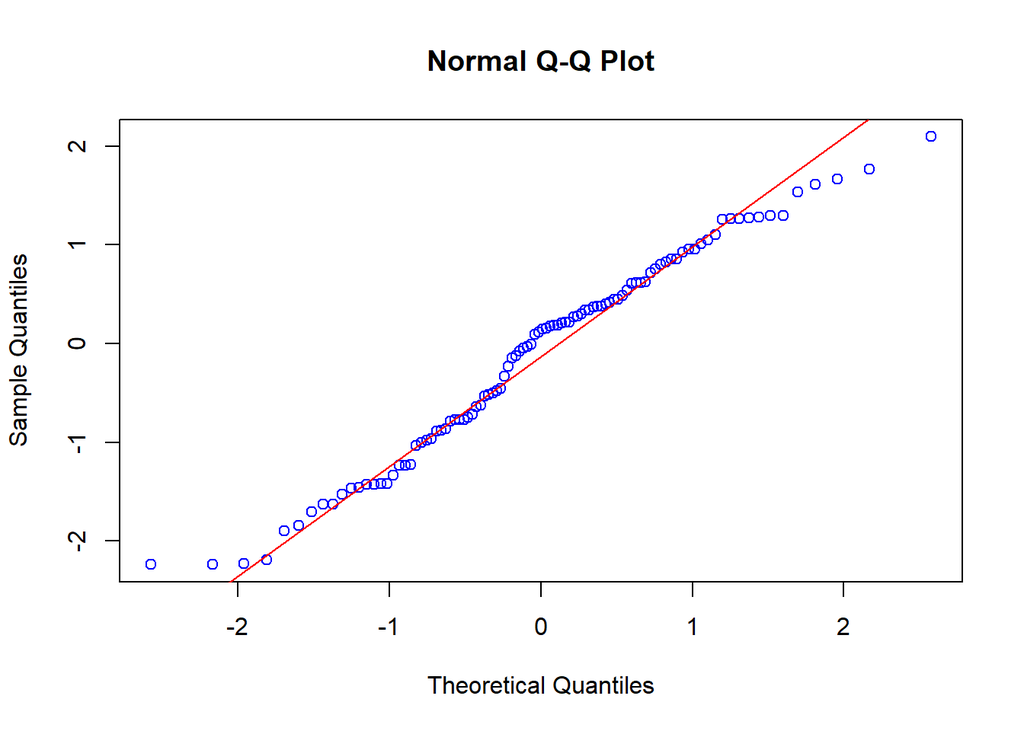

```r
x <- sample(rnorm(500),100,replace = TRUE)   # veri tanimlamasi

qqnorm(x , col = "blue")   # Q-Q grafiginin olusturulmasi
qqline(x , col = "red")    # 45 derecelik acinin cizilmesi
```